# DS202: Homework 5

Muhammad Khairi Norizan

11/9/2021

## Data Engineering

```r
# import library
library(tidyverse)
library(lubridate)
library(ggplot2)
library(dplyr)

# import data set
dataframe <- read_csv("2021_Iowa_Liquor_Sales.csv")

# data cleaning
dataframe$Date <- mdy(dataframe$Date)
dataframe <- dataframe %>%
              separate(`Store Location`, c('POINT', 'Longitude', 'Latitude'), " ", convert = TRUE) %>%
              separate(`Longitude`, c('SymbolLon','Longitude'), sep ='\\(') %>%
              separate(`Latitude`, c('Latitude','SymbolLat'), sep ='\\)') %>%
              select(-c('POINT', 'SymbolLon', 'SymbolLat'))
```

## Question 1

First overview: Provide a visual breakdown of the liquor category (by `Category Name`). Include volume sold in the breakdown. Describe your figure. Which type of liquor is the most popular?

```r
categoryBreakdown <- dataframe %>%
                      group_by(`Category Name`) %>%
                      summarize(VolumeSold = sum(`Volume Sold (Gallons)`, na.rm = TRUE)) %>%
                      arrange(desc(VolumeSold))

print(categoryBreakdown)
```

```
## # A tibble: 51 × 2
##    `Category Name`           VolumeSold
##    <chr>                          <dbl>
##  1 American Vodkas               33198.
##  2 Canadian Whiskies             13510.
##  3 Straight Bourbon Whiskies     10345.
##  4 Cocktails /RTD                 8073.
##  5 White Rum                      7795.
##  6 American Flavored Vodka        7541.
##  7 Spiced Rum                     7311.
##  8 Flavored Rum                   5189.
##  9 Whiskey Liqueur                4384.
## 10 Imported Vodkas                4043.
## # … with 41 more rows
```

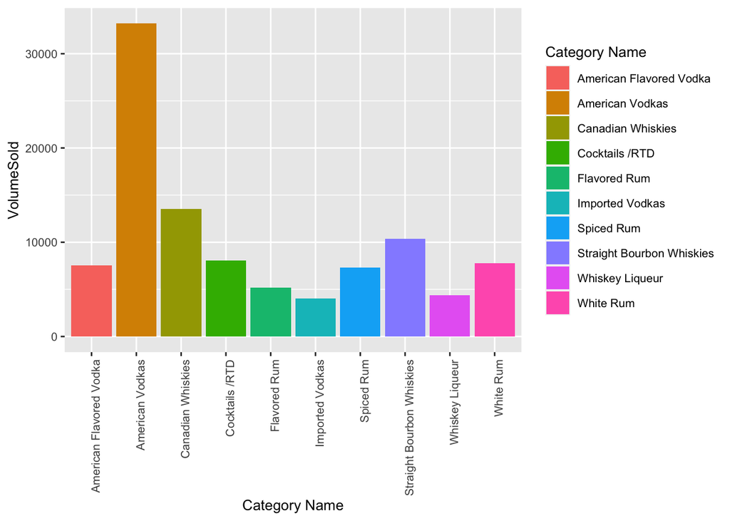

```r
top10Category <- categoryBreakdown %>% head(10)

ggplot(top10Category, aes(x=`Category Name`, y=VolumeSold, fill = `Category Name`)) +
  geom_bar(stat = "identity") +
  theme(text = element_text(size=10), axis.text.x = element_text(angle = 90, hjust=1))
```

## Question 2

Which day of the week has the most orders? Use a barchart to visualize the results. Explain the pattern and provide a reason why the pattern occurs.

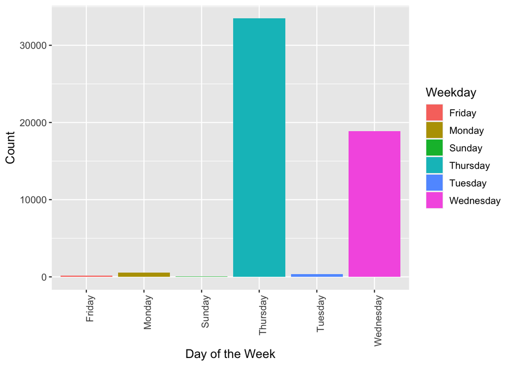

```r
dfWithWeekday <- dataframe %>% mutate(Weekday = weekdays(Date))

weekdayBreakdown <- dfWithWeekday %>%
                      group_by(Weekday) %>%
                      count(Weekday, sort = TRUE)

ggplot(weekdayBreakdown, aes(x=Weekday, y=n, fill = Weekday)) +
  geom_bar(stat = "identity") +
  theme(text = element_text(size=12), axis.text.x = element_text(angle = 90, hjust=1)) +
  labs(y = "Count", x = "Day of the Week")
```

The graph above shows the relationship between the number of orders and day of the week. Apparently, Thursday and Wednesday are the day when people in Ames mostly purchase liquor. However, between Thursday and Wednesday, Thursday has the most number of orders compared to the other days. There are many factors that contribute to the graph pattern.  
One of the factors that contribute to high orders on Thursday is Mug Night. Mug Night happens every Thursday night in Campustown where a handful of bars such as Cy’s Roost, Paddy’s, Mickie’s and few other bars carry on the tradition of making plastic 32-ounce beer mugs available for purchase or refilled at a cheaper price.  
The high orders on Wednesday may be contributed by Dollar Drinks Wednesday. As the name suggest, Dollar Drinks Wednesday occurs every Wednesday night in Campustown. On top of a handful of bars sells drink only for a dollar, BNC Fieldhouse - a sports bar in campustown - also hosts comedy night on Wednesday where The Iowa State stand-up comedy club can be spotted there.

## Question 3

Create a single plot for the monthly volumes sold. Each liquor category should be shown using a separate time series. Label the top 5 categories using text labels.

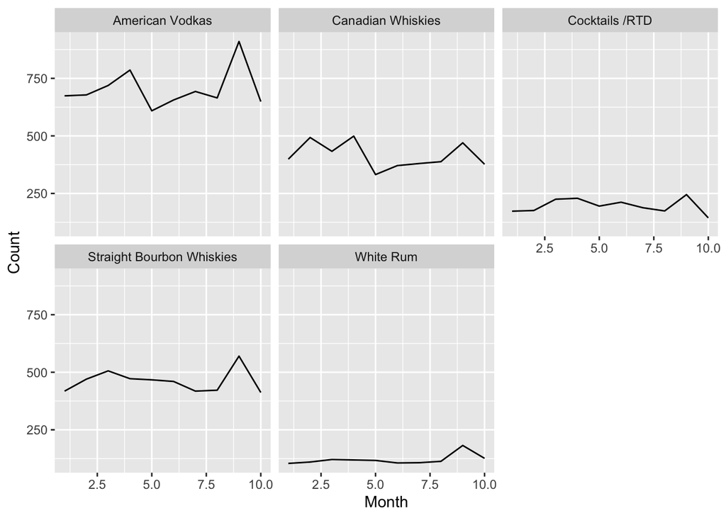

```r
dfWithMonth <- dataframe %>% mutate(Month = month(Date))

categoryMonthBreakdown <- dfWithMonth %>%
                          group_by(`Category Name`, Month) %>%
                          count(`Category Name`, Month, sort = TRUE)

top5Category <- categoryBreakdown %>% head(5)

top5MonthlyBreakdown <- categoryMonthBreakdown %>%
                        filter(`Category Name` %in% top5Category$`Category Name`) %>%
                        arrange(desc(`Category Name`))

ggplot(top5MonthlyBreakdown, aes(x=Month, y=n)) +
  geom_line() +
  facet_wrap(~`Category Name`) +
  labs(y = "Count")
```

## Question 4

Which categories are spring graduation party favorites? Find at least one category.

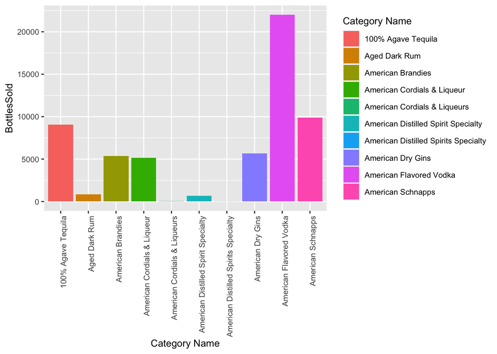

```r
dfWithSemester <- dfWithMonth %>%
                  mutate(Semester = semester(Date)) %>%
                  mutate(Semester = ifelse(Semester == 1, "Spring", "Fall"))


categorySemesterBreakdown <- dfWithSemester %>%
                              filter(Semester == 'Spring') %>%
                              group_by(`Category Name`) %>%
                              summarize(BottlesSold = sum(`Bottles Sold`, na.rm = TRUE))

top10CategoryBySemester <- categorySemesterBreakdown %>% head(10)

ggplot(top10CategoryBySemester, aes(x=`Category Name`, y=BottlesSold, fill = `Category Name`)) +
  geom_bar(stat = "identity") +
  theme(text = element_text(size=10), axis.text.x = element_text(angle = 90, hjust=1))
```